# Indel Signature InsDel_J

# InsDel_J

**Note**

InsDel_J and InsDel_N cannot be distinguished in the 89-type representation because the differences between them are completely contained in the set of deletions classified as L(2, ):U(1,2):R(5, ). These deletions can be distinguished in the 83-type classification and, with difficulty, in the 476-type classification.

(corresponds to 83-type signature ID_J)

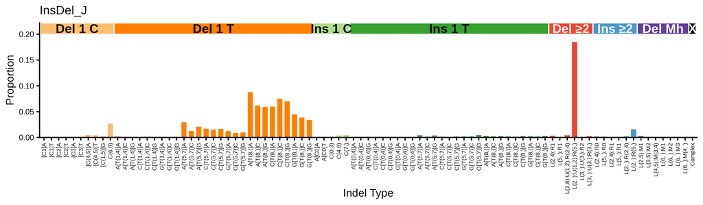

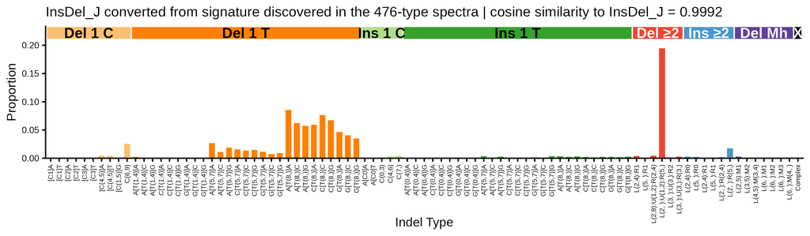

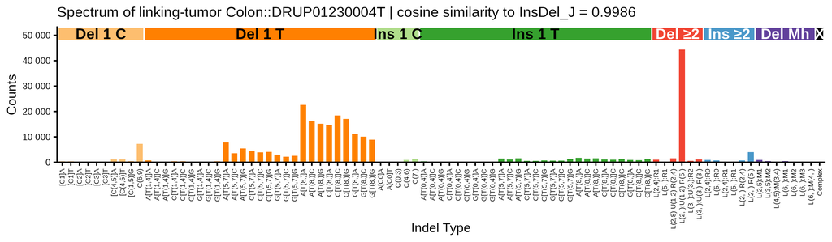

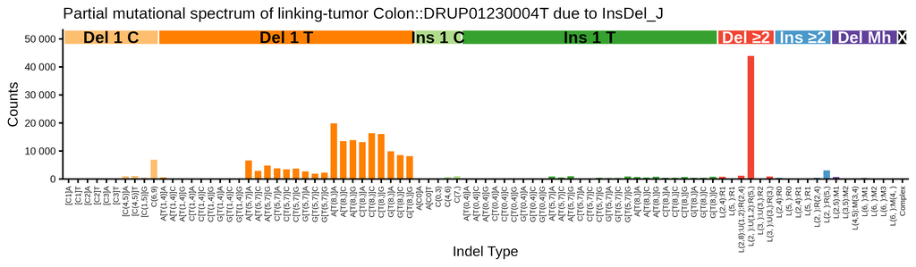

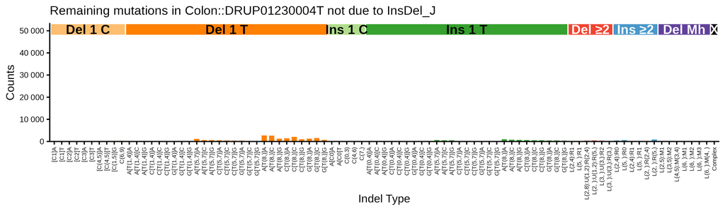

## 476-type representations corresponding to InsDel_J

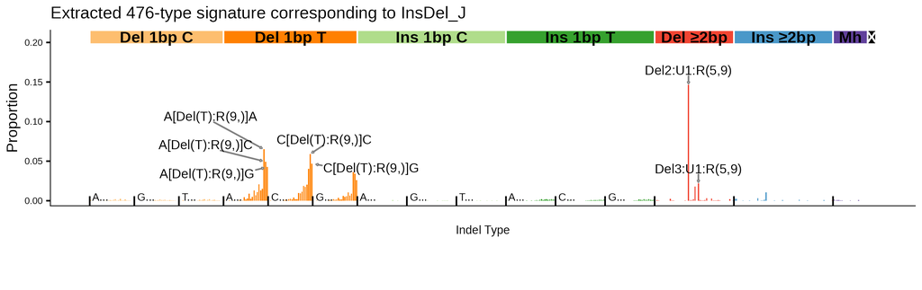

476-type spectrum of the linking tumor Colon::DRUP01230004T; cosine similarity to the extracted 476-type signature is 0.9932

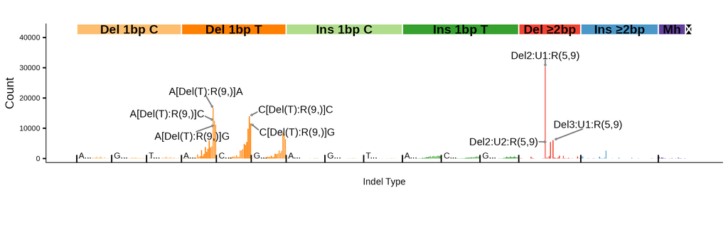

## 83-type signature corresponding to InsDel_J (ID_J)

**Note**

ID_J shows a higher proportion of 2bp deletions occurring within the longest class of 2bp simple tandem repeats (≥5 repeat units) compared with ID_N. In contrast, ID_N is characterized by a greater frequency of 2bp deletions in 4‑unit tandem repeats, plus some 3bp and 4bp deletions.

WARNING: The 83-type ID_J extraction excluded the large proportion (60%) of T deletions in long poly-T contexts that were detected in extractions in the 89-type and 476-type classifications.

These single T deletions in long poly-T contexts are present in the 83-type signature collapsed from the 476-type InsDel_J signature, which makes the deletions of 2 bases hard to see in the plot. However, since we are collapsing from 476-categories that also do not capture the differences between InsDel_J (89-type representation of ID_J) and InsDel_N (89-type representation of ID_N) very well, the differences between InsDel_J and InsDel_N are not visible.

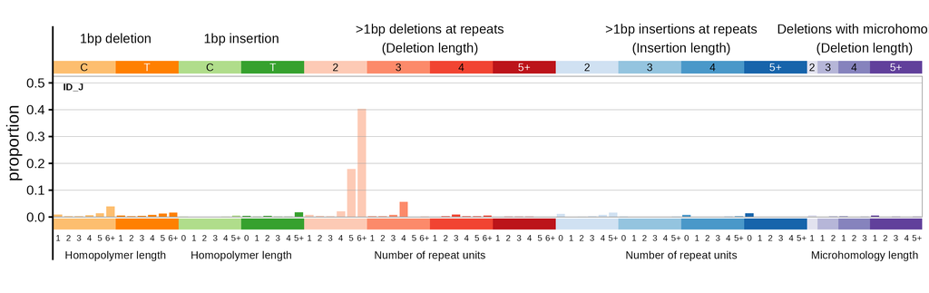

83-type signature converted from signature discovered in the 476-type spectra | cosine similarity to ID_J: 0.05734

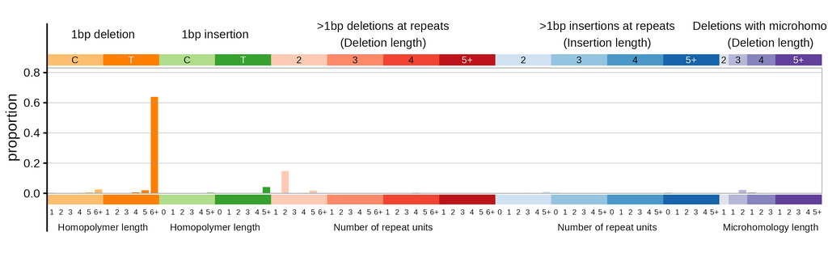

**Click here to see with insertions and deletions of T in long poly-T suppressed**

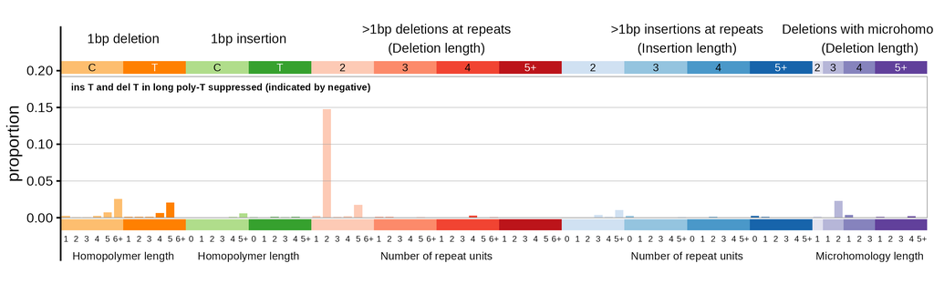

**Caution**

For the linking tumor plot, mutation counts for insertions and deletions of T in long-poly-T contexts were set to 0. They were also set to 0 when calculating cosine similarity with the signature. The signature was not altered when computing the cosine similarity.

83-type spectrum of the linking tumor Colon::DRUP01230004T | cosine similarly to ID_J: 0.9413

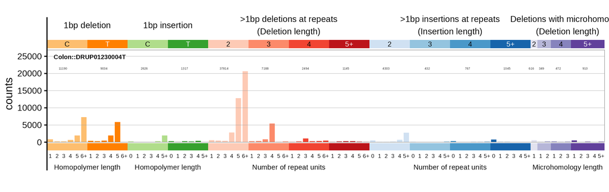